# Лабораторная работа №2

Основы администрирования операционных систем

Верниковская Е. А., НПИбд-01-23

Российский университет дружбы народов, Москва, Россия

10 сентября 2024

# Вводная часть

## Цель работы

Получить представление о работе с учётными записями пользователей и группами пользователей в операционной системе типа Linux.

## Задание

1. Прочитать справочное описание man по нескольким командам.
2. Выполнить действия по переключению между учётными записями пользователей, по управлению учётными записями пользователей.
3. Выполнить действия по созданию пользователей и управлению их учётными записями.
4. Выполнить действия по работе с группами пользователей.

# Выполнение лабораторной работы

## Справочное описание команд

Открываем терминал и читаем справочное описание man по командам ls, whoami, id, groups, su, sudo, passwd, vi, visudo, useradd, usermod, userdel, groupadd, groupdel (рис. 1)

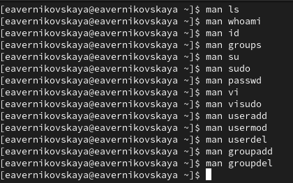

Команда man

## Переключение учётных записей пользователей

Входим в систему как обычный пользователь и открываем терминал. Определяем, какую учётную запись пользователя мы используем, введя команду *whoami* (рис. 2)

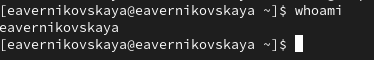

Команда whoami

## Переключение учётных записей пользователей

Выводим на экран более подробную информацию, используя команду *id*. Пояснение: UID – id пользователя равный 1000; GID – id группы равный 1000 (рис. 3)

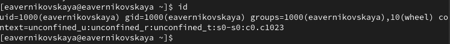

Команда id для нашей учётной записи

## Переключение учётных записей пользователей

Используем команду *su* для переключения к учётной записи root. При запросе пароля вводим пароль пользователя root (рис. 4)

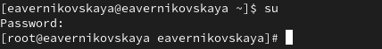

Команда su

## Переключение учётных записей пользователей

Снова выводим на экран более подробную информацию командой *id*. Пояснение: UID – id пользователя равный 0; GID – id группы равный 0 (рис. 5)

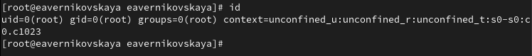

Команда id для root

## Переключение учётных записей пользователей

Возвращаемся к учётной записи нашего пользователя *su имя_пользователя* (рис. 6)

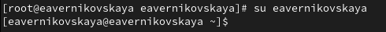

Учётная запись нашего пользователя

## Переключение учётных записей пользователей

Смотрим в безопасном режиме файл /etc/sudoers, используя *sudo -i visudo* (рис. 7), (рис. 8)

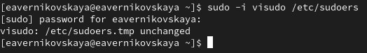

Окрытие файла /etc/sudoers

## Переключение учётных записей пользователей

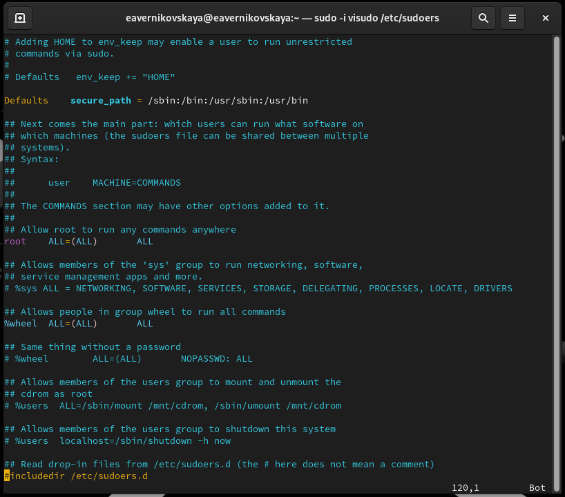

Файл /etc/sudoers

## Переключение учётных записей пользователей

Пояснение: неправильный синтаксис файла /etc/sudoers может нарушить работу системы и сделать невозможным получение повышенного уровня привилегий, и поэтому очень важно использовать для его редактирования команду visudo. Команда visudo открывает текстовый редактор обычным образом, но проверяет синтаксис файла при его сохранении. Это не даст ошибкам конфигурации возможности блокировать операции sudo, что может быть единственным способом получить привилегии root

## Переключение учётных записей пользователей

Далее создаём пользователя alice, входящего в группу wheel (рис. 10)

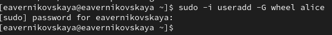

Создание пользователя alice

## Переключение учётных записей пользователей

Проверяем что пользователь alice добавлен в группу wheel, введя *id alice* (рис. 11)

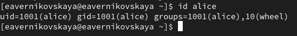

Команда id для alice

## Переключение учётных записей пользователей

Задаём пароль для пользователя alice, набрав *sudo -i passwd alice* (рис. 12)

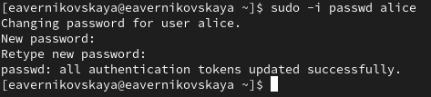

Пароль для alice

## Переключение учётных записей пользователей

Далее переключаемся на учётную запись пользователя alice (рис. 13)

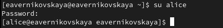

Учётная запись alice

## Переключение учётных записей пользователей

Создаём пользователя bob (рис. 14)

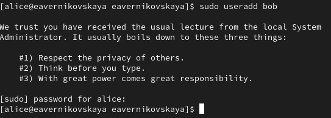

Создание пользователя bob

## Переключение учётных записей пользователей

Задаём пароль для пользователя bob (рис. 15)

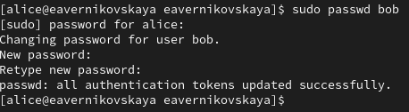

Пароль для bob

## Переключение учётных записей пользователей

Посмотрим, в какие группы входит пользователь bob (рис. 16)

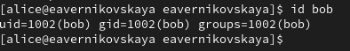

Группы пользователя bob

## Создание учётных записей пользователей

Переключаемся в терминале на учётную запись пользователя root (рис. 17)

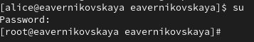

Переключение на root

## Создание учётных записей пользователей

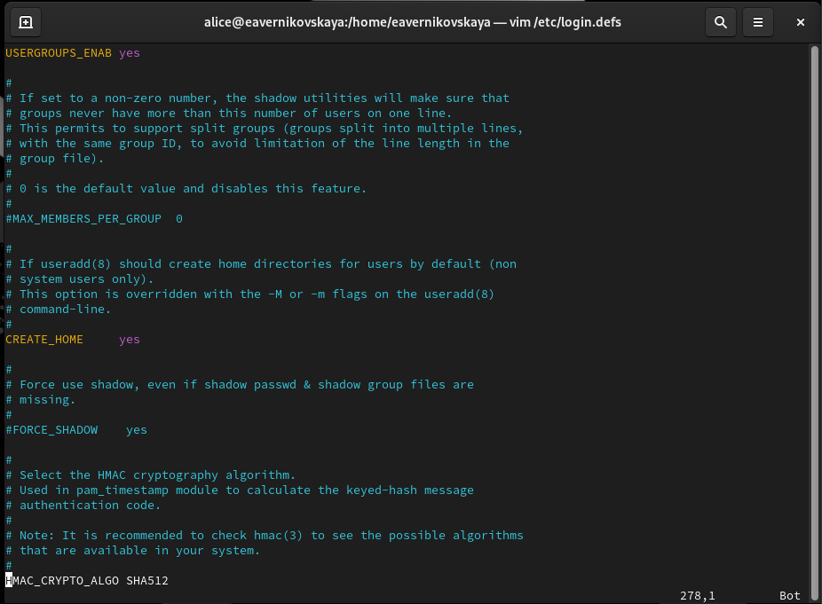

Файл /etc/login.defs

## Создание учётных записей пользователей

Создаём каталоги Pictures и Documents (рис. 23)

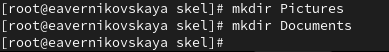

Каталоги Pictures и Documents

## Создание учётных записей пользователей

Открываем файл .bashrc (рис. 24), (рис. 25)

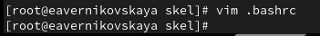

Открытие файла .bashrc

## Создание учётных записей пользователей

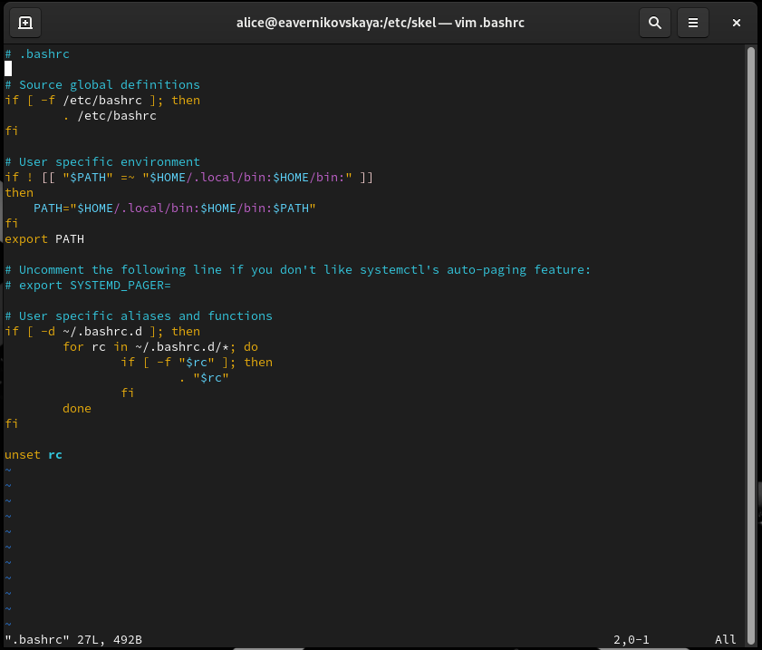

Файла .bashrc

## Создание учётных записей пользователей

Добавляем в него строку export EDITOR=/usr/bin/vim. Эта запись означает, что текстовый редактор vim будет установлен по умолчанию для инструментов, которые нуждаются в изменении текстовых файлов (рис. 26)

## Создание учётных записей пользователей

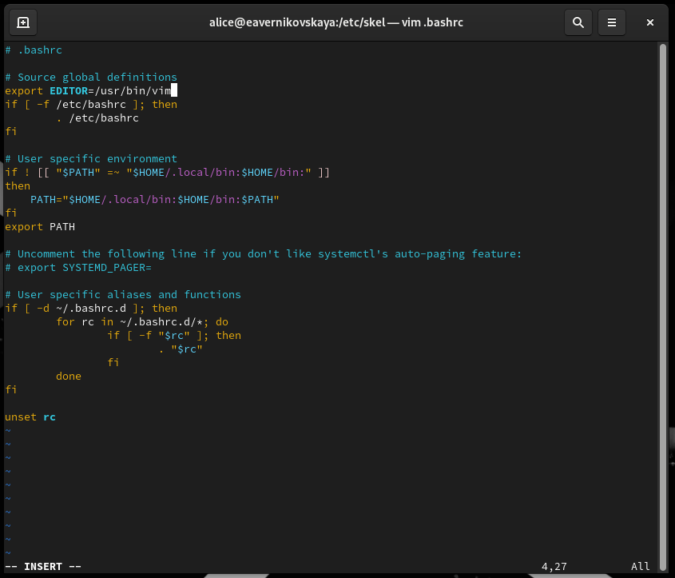

Редактирование файла .bashrc

## Создание учётных записей пользователей

Используя утилиту *useradd*, создаём пользователя carol (рис. 28)

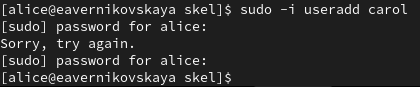

Создание пользователя carol

## Создание учётных записей пользователей

Далее устанавливаем пароль для пользователя carol (рис. 29)

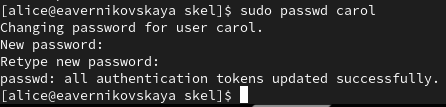

Пароль для carol

## Создание учётных записей пользователей

Далее смотрим информацию о пользователе carol:

- с помощью команды *id* выясняем что пользователь carol входит в группу users
- далее переходим в домашний каталог с помощью *cd* и смотрим командой *ls -Al*, что каталоги и Pictures и Documents были созданы в домашнем каталоге пользователя carol (рис. 30)

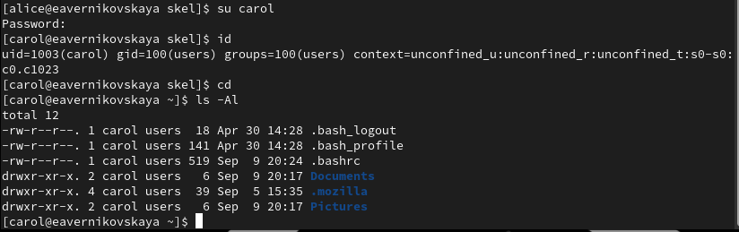

Информация о carol и о созданных каталогах